# Homework 2

Author

Megan Brown

Github repo: https://github.com/mabrownnyu/stats506

```r
library(microbenchmark)
```

# Problem 1

## Problem 1(a)

### Version 1

```r
#' forLoopWalk (creates a random walk using a for loop)
#'
#' @param num An integer representing the number of steps we want to take
#'            in the walk
#' @param seed The random seed if desired, must be an integer
#'
#' @returns The final position from the walk
forLoopWalk <- function(num, seed=FALSE){

  # set random seed if there is one
  if(seed){
    set.seed(seed)
  }

  # start at position zero
  positions <- 1:num

  # for each step, sample 1 or -1
  # then based on 1 or -1, choose 1, -1, -3, or 10
  for (step in 1:num){
    outcomes = c(1, -1, 10, -3)
    probabilities = c(0.475, 0.4, 0.025, 0.1)
    positions[step] = sample(outcomes, 1, prob=probabilities)
  }

  position <- 0
  for (i in positions){
    position <- position + i
  }
  # return the final position
  return(position)
}
```

### Version 2

```r
#' vectorWalk (creates a random walk using R's built-in vectorization)
#'
#' @param num An integer representing the number of steps we want to take
#'            in the walk
#' @param seed The random seed if desired, must be an integer
#'
#' @returns The final position from the walk
vectorWalk <- function(num, seed=FALSE){
  if(seed){
    set.seed(seed)
  }
  # get a sample of every step with the according probabilities
  positions <- sample(c(1, -1, 10, -3), size=num, prob=c(0.475, 0.4, 0.025, 0.1), replace=TRUE)

  # sum over steps to get the final positions
  position <- sum(positions)
  return(position)
}
```

### Version 3

```r
#' applyWalk (creates a random walk using R's apply function)
#'
#' @param num An integer representing the number of steps we want to take
#'            in the walk
#' @param seed The random seed if desired, must be an integer
#'
#' @returns The final position from the walk
applyWalk <- function(num, seed=FALSE){

  if(seed){
    set.seed(seed)
  }
  # set array
  positions <- 1:num
  # for each position, return a step based on the probabilities
  positions <- sapply(positions, FUN=function(x){
    return(sample(x=c(1, -1, 10, -3), size=1, prob=c(0.475, 0.4, 0.025, 0.1)))
  })

  # add steps to find final position
  return(sum(unlist(positions)))
}
```

### Verification that this worked

```r
# for ten samples
print(forLoopWalk(10))
```

```
[1] -2
```

```r
print(vectorWalk(10))
```

```
[1] 4
```

```r
print(applyWalk(10))
```

```
[1] 9
```

```r
# for 1k samples
print(forLoopWalk(1000))
```

```
[1] 105
```

```r
print(vectorWalk(1000))
```

```
[1] 83
```

```r
print(applyWalk(1000))
```

```
[1] -5
```

## Problem 1(b)

```r
forLoopWalk(10, seed=330)
```

```
[1] -14
```

```r
vectorWalk(10, seed=330)
```

```
[1] -14
```

```r
applyWalk(10, seed=330)
```

```
[1] -14
```

```r
forLoopWalk(100, seed=330)
```

```
[1] 8
```

```r
vectorWalk(100, seed=330)
```

```
[1] 8
```

```r
applyWalk(100, seed=330)
```

```
[1] 8
```

## Problem 1(c)

```r
microbenchmark(vw1k=vectorWalk(1000),
               vw100k=vectorWalk(100000),
               flw1k=forLoopWalk(1000),
               flw100k=forLoopWalk(100000),
               aw1k=applyWalk(1000),
               aw100k=applyWalk(100000),
               unit="seconds"
               )
```

```
Unit: seconds
    expr         min          lq         mean       median           uq
    vw1k 0.000037433 0.000045469 5.725732e-05 0.0000515575 0.0000613975
  vw100k 0.002838553 0.003250931 4.094672e-03 0.0036954325 0.0043581975
   flw1k 0.004024191 0.004333003 7.163360e-03 0.0051526750 0.0066785105
 flw100k 0.414436487 0.476226665 5.995279e-01 0.5153218660 0.6667880840
    aw1k 0.004461538 0.005096423 7.823676e-03 0.0060510260 0.0076852040
  aw100k 0.484614957 0.552024984 7.394504e-01 0.6311973780 0.8606654605
         max neval
 0.000185525   100
 0.011456097   100
 0.098506805   100
 1.398107667   100
 0.074866615   100
 1.676634771   100
```

The vector walk is the fastest, and the for-loop and apply functions are slower. This is because the for loop walk is interpreted at every step of the for loop. The apply function is also not vectorized.

## Problem 1(d)

```r
n <- 10000
tests10 <- 1:n
tests10 <- sapply(tests10, FUN=vectorWalk, num=10)
100 * sum(tests10==0) / length(tests10)
```

```
[1] 13.32
```

```r
tests100 <- 1:n
tests100 <- sapply(tests100, FUN=vectorWalk, num=100)
100 * sum(tests100==0) / length(tests100)
```

```
[1] 2.05
```

```r
tests1k <- 1:n
tests1k <- sapply(tests1k, FUN=vectorWalk, num=1000)
100 * sum(tests1k==0) / length(tests1k)
```

```
[1] 0.59
```

When the number of steps is 10, the probability of the final step of the walk being 0 is 13.3%. When the number of steps is 100, the probability of the final step of the walk being 0 is 2.1%. When the number of steps is 1000, the probability of the final step of the walk being being 0 is 0.6%. I estimated these values by conducting 10k of the random walks and then calculating the number of times the final step was 0.

# Problem 2

```r
#' sampleDay (for n days, sample the number of cars based on the distribution per hour)
#'
#' @param n An integer representing the number of days we want to sample
#'
#' @returns The average number of cars per day
sampleDay <- function(n){
  # eight hours between midnight and seven
  midnight_to_seven <- rpois(n*8, lambda=1)
  # eight hours between nine and four
  nine_to_four <- rpois(n*8, lambda=8)
  # eight hours between six and eleven
  six_to_eleven <- rpois(n*6, lambda=12)
  # two hours for eight and five
  eight_and_five <- rnorm(n*2, mean=60, sd=sqrt(12))

  # sum total number of cars for every day
  total_cars <- sum(c(midnight_to_seven, nine_to_four, six_to_eleven, eight_and_five))

  # divide by number of days for average
  avg <- total_cars/n
  return(avg)
}

print(paste0("With 100 samples: ", sampleDay(100)))
```

```
[1] "With 100 samples: 264.30327147595"
```

```r
print(paste0("With 1k samples: ", sampleDay(1000)))
```

```
[1] "With 1k samples: 263.743365410051"
```

```r
print(paste0("With 10k samples: ", sampleDay(10000)))
```

```
[1] "With 10k samples: 263.943480283393"
```

```r
print(paste0("With 100k samples: ", sampleDay(100000)))
```

```
[1] "With 100k samples: 263.981251652448"
```

The average number of cars that passes through the intersection every day is 264.

# Problem 3

```r
youtube <- read.csv('https://raw.githubusercontent.com/rfordatascience/tidytuesday/master/data/2021/2021-03-02/youtube.csv')
```

## Problem 3(a)

```r
# filter to columns without identifying information
youtube <- youtube[,c("year", "funny", "show_product_quickly",
                      "patriotic", "celebrity", "danger", "animals",
                      "use_sex", "kind", "view_count", "like_count",
                      "dislike_count", "favorite_count", "comment_count",
                      "published_at", "category_id")]

dim(youtube)
```

```
[1] 247  16
```

The resulting dimensions are 247 rows and 16 columns.

## Problem 3(b)

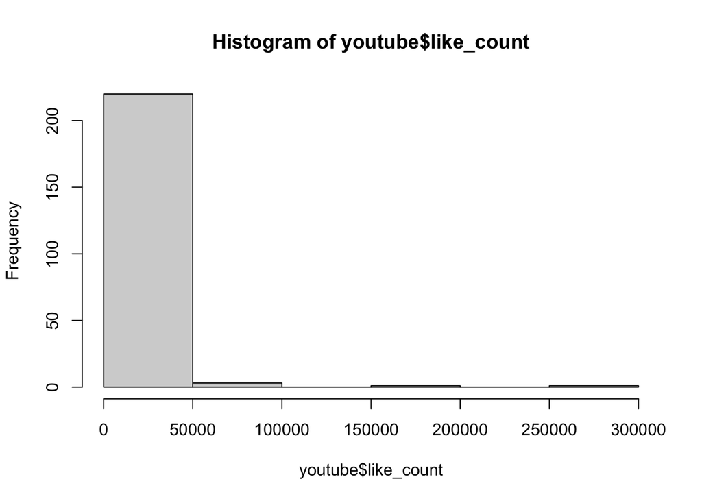

```r
# likes
hist(youtube$like_count)
```

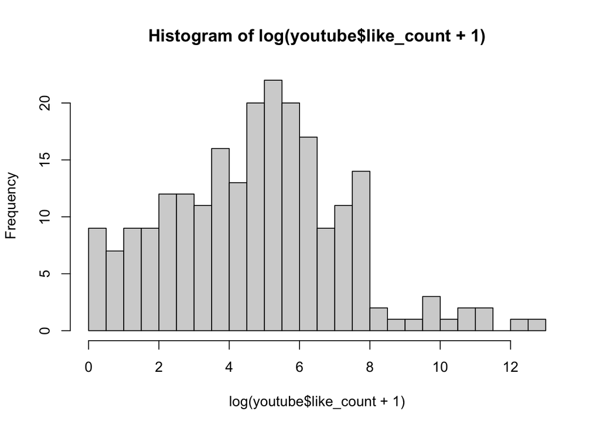

```r
hist(log(youtube$like_count + 1), breaks=20)
```

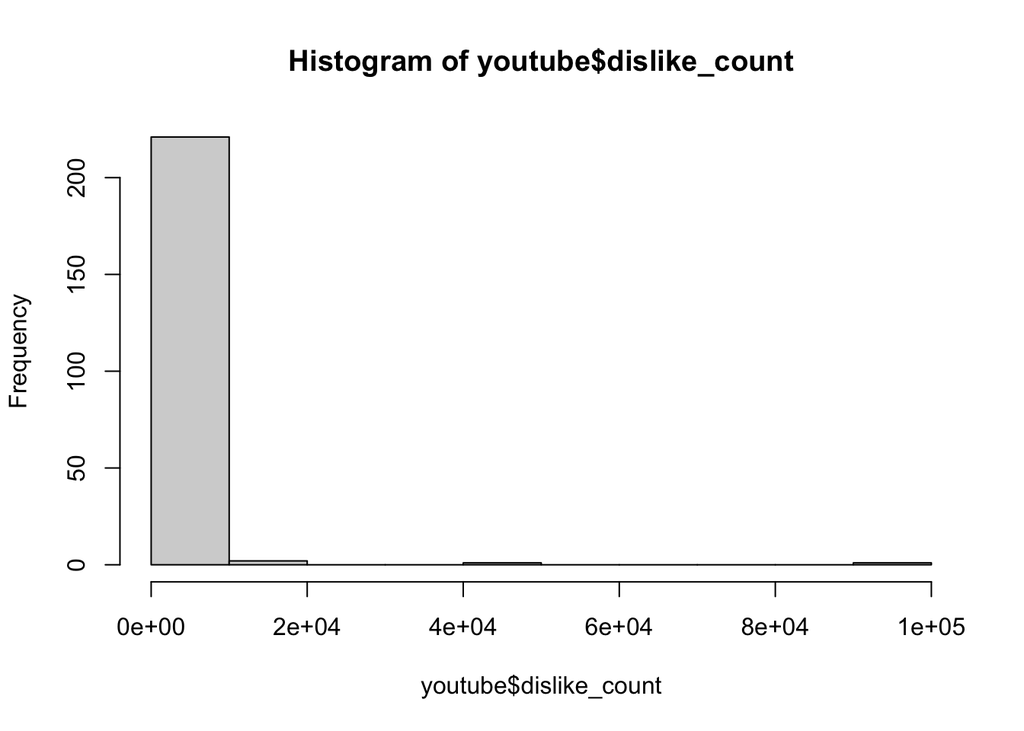

```r
# dislikes
hist(youtube$dislike_count)
```

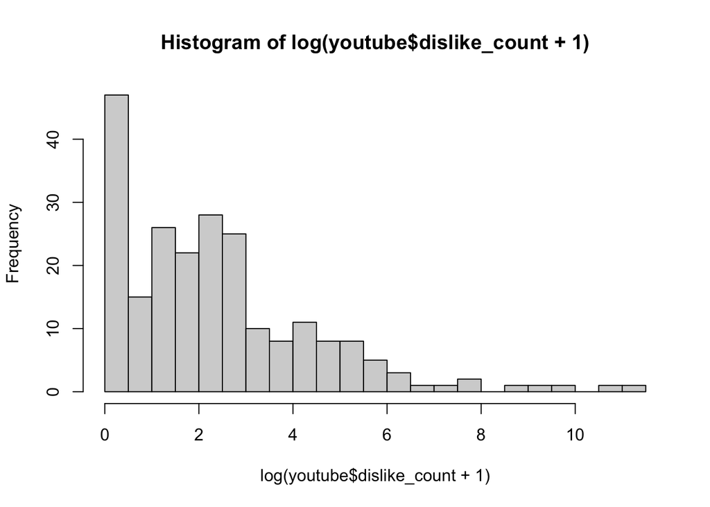

```r
hist(log(youtube$dislike_count + 1), breaks=20)
```

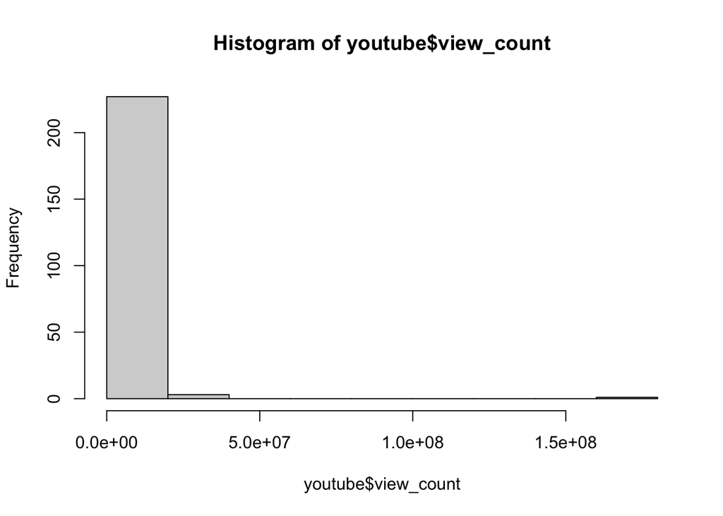

```r
# views
hist(youtube$view_count)
```

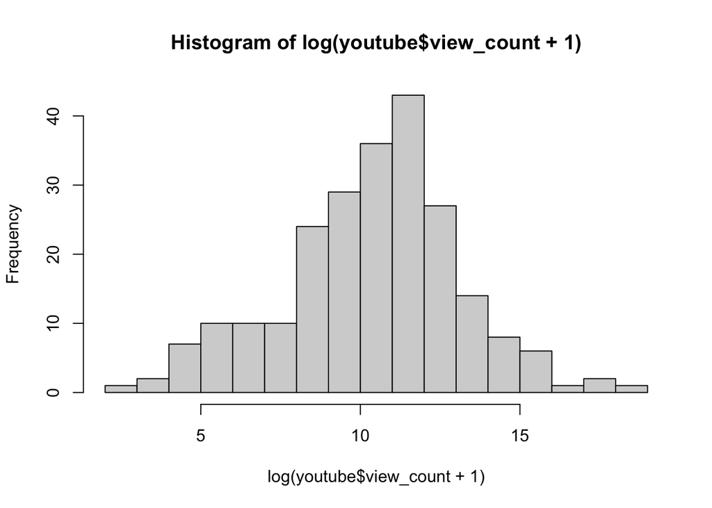

```r
hist(log(youtube$view_count + 1), breaks=20)
```

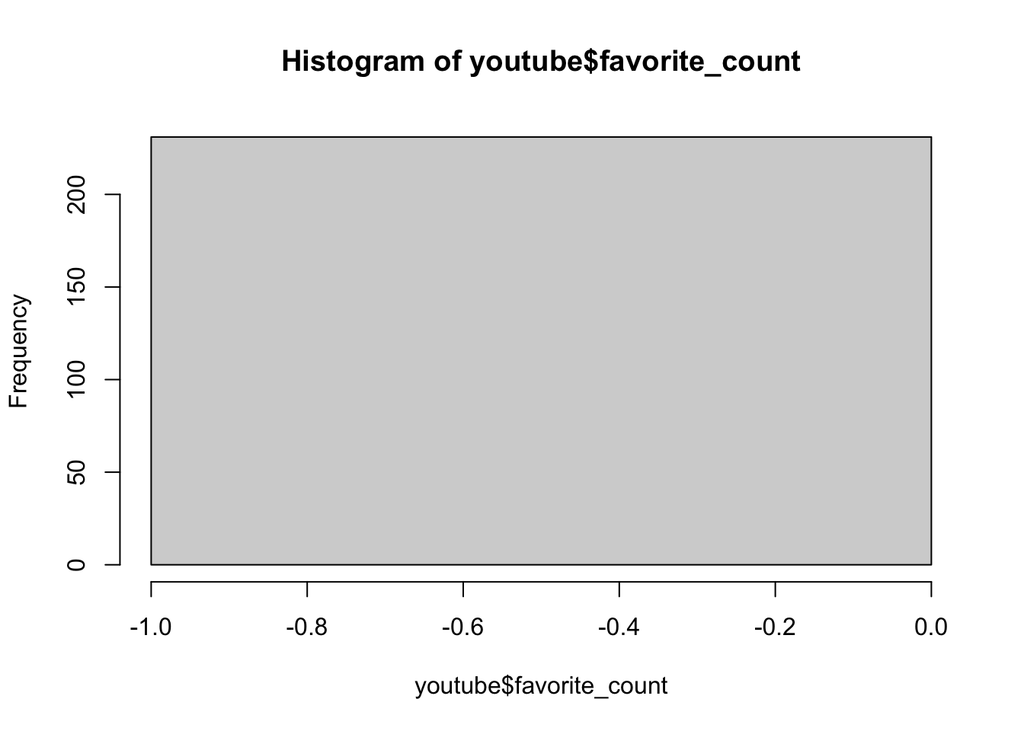

```r
# favorites
hist(youtube$favorite_count)
```

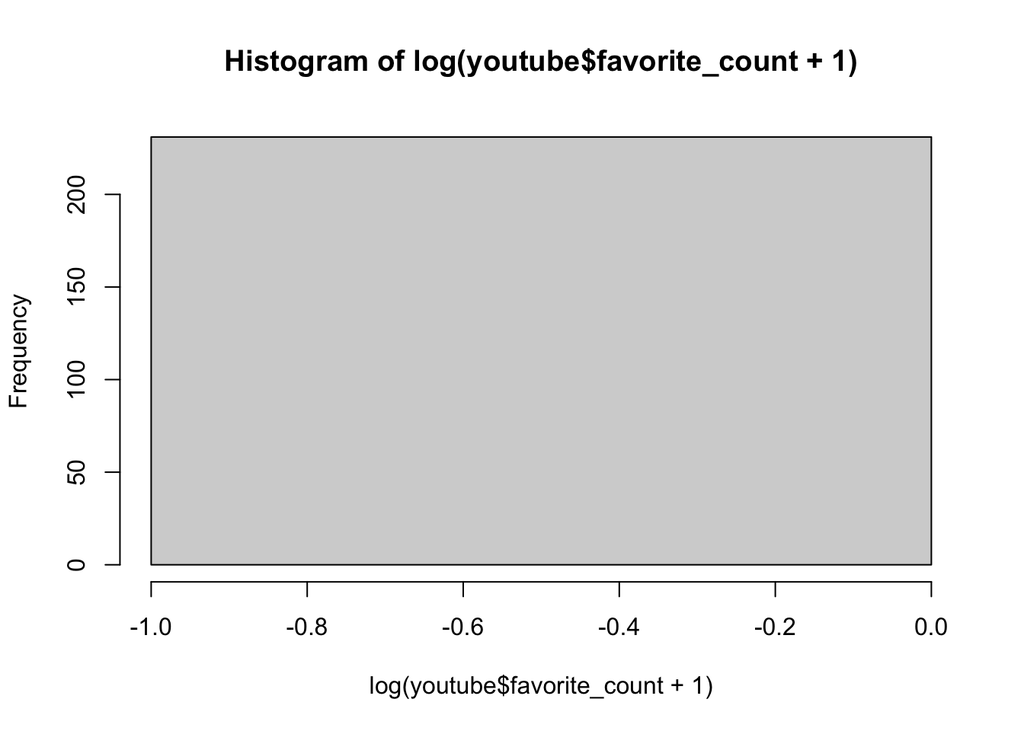

```r
hist(log(youtube$favorite_count + 1), breaks=20)
```

`favorite_count` is not suitable because there is not variation in the values.

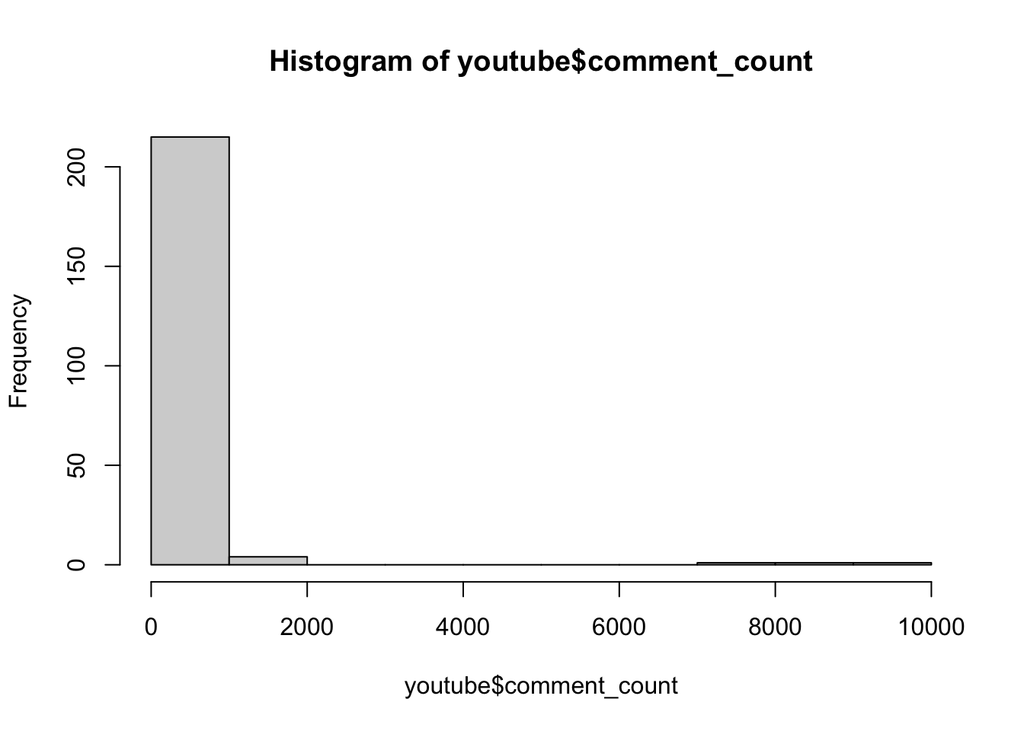

```r
# comments
hist(youtube$comment_count)
```

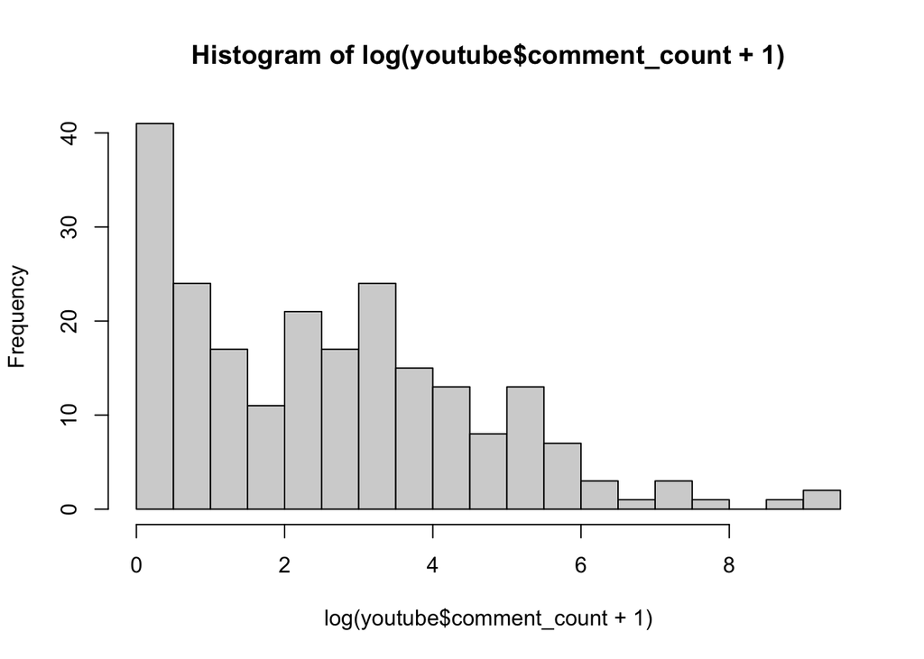

```r
hist(log(youtube$comment_count + 1), breaks=20)
```

```r
# do transformations discussed above
youtube$view_count <- log(youtube$view_count + 1)
youtube$like_count <- log(youtube$like_count + 1)
youtube$dislike_count <- log(youtube$dislike_count + 1)
youtube$comment_count <- log(youtube$comment_count + 1)

# transform true/false columns into integers
for (col in c("funny", "show_product_quickly", "patriotic",
              "celebrity", "danger", "animals", "use_sex")){
  youtube[,col] <- as.integer(youtube[,col])
}
```

## Problem 3(c)

### Views

```r
views <- lm(view_count ~ funny + show_product_quickly + patriotic
            + celebrity + danger + animals + use_sex + year, data=youtube
            )
summary(views)
```

```
Call:
lm(formula = view_count ~ funny + show_product_quickly + patriotic +
    celebrity + danger + animals + use_sex + year, data = youtube)

Residuals:
    Min      1Q  Median      3Q     Max
-7.7742 -1.6152  0.1311  1.7036  8.4481

Coefficients:
                      Estimate Std. Error t value Pr(>|t|)
(Intercept)          -31.55016   71.00538  -0.444    0.657
funny                  0.56492    0.46702   1.210    0.228
show_product_quickly   0.21089    0.40530   0.520    0.603
patriotic              0.50699    0.53811   0.942    0.347
celebrity              0.03548    0.42228   0.084    0.933
danger                 0.63131    0.41812   1.510    0.132
animals               -0.31002    0.39348  -0.788    0.432
use_sex               -0.38671    0.44782  -0.864    0.389
year                   0.02053    0.03531   0.582    0.561

Residual standard error: 2.787 on 222 degrees of freedom
  (16 observations deleted due to missingness)
Multiple R-squared:  0.02694,   Adjusted R-squared:  -0.008122
F-statistic: 0.7684 on 8 and 222 DF,  p-value: 0.631
```

### Likes

```r
likes <- lm(like_count ~ funny + show_product_quickly + patriotic
            + celebrity + danger + animals + use_sex + year, data=youtube
            )
summary(likes)
```

```
Call:
lm(formula = like_count ~ funny + show_product_quickly + patriotic +
    celebrity + danger + animals + use_sex + year, data = youtube)

Residuals:
    Min      1Q  Median      3Q     Max
-5.2860 -1.6333  0.0868  1.4911  7.7431

Coefficients:
                       Estimate Std. Error t value Pr(>|t|)
(Intercept)          -150.51357   63.45723  -2.372   0.0186 *
funny                   0.47476    0.41816   1.135   0.2575
show_product_quickly    0.20017    0.36391   0.550   0.5828
patriotic               0.80689    0.49791   1.621   0.1066
celebrity               0.41283    0.38212   1.080   0.2812
danger                  0.63895    0.37350   1.711   0.0886 .
animals                -0.05944    0.35298  -0.168   0.8664
use_sex                -0.42952    0.40064  -1.072   0.2849
year                    0.07685    0.03155   2.436   0.0157 *
---
Signif. codes:  0 '***' 0.001 '**' 0.01 '*' 0.05 '.' 0.1 ' ' 1

Residual standard error: 2.467 on 216 degrees of freedom
  (22 observations deleted due to missingness)
Multiple R-squared:  0.07313,   Adjusted R-squared:  0.03881
F-statistic:  2.13 on 8 and 216 DF,  p-value: 0.0342
```

### Dislike Count

```r
dislikes <- lm(dislike_count ~ funny + show_product_quickly + patriotic
            + celebrity + danger + animals + use_sex + year, data=youtube
            )
summary(dislikes)
```

```
Call:
lm(formula = dislike_count ~ funny + show_product_quickly + patriotic +
    celebrity + danger + animals + use_sex + year, data = youtube)

Residuals:
    Min      1Q  Median      3Q     Max
-4.0292 -1.3299 -0.3192  0.8986  8.7219

Coefficients:
                       Estimate Std. Error t value Pr(>|t|)
(Intercept)          -183.06813   53.34768  -3.432 0.000719 ***
funny                   0.25949    0.35154   0.738 0.461224
show_product_quickly    0.27511    0.30593   0.899 0.369515
patriotic               0.81407    0.41859   1.945 0.053095 .
celebrity              -0.20214    0.32125  -0.629 0.529852
danger                  0.22184    0.31400   0.707 0.480630
animals                -0.21192    0.29675  -0.714 0.475911
use_sex                -0.32980    0.33681  -0.979 0.328583
year                    0.09207    0.02653   3.471 0.000626 ***
---
Signif. codes:  0 '***' 0.001 '**' 0.01 '*' 0.05 '.' 0.1 ' ' 1

Residual standard error: 2.074 on 216 degrees of freedom
  (22 observations deleted due to missingness)
Multiple R-squared:  0.09753,   Adjusted R-squared:  0.06411
F-statistic: 2.918 on 8 and 216 DF,  p-value: 0.004115
```

### Comment Count

```r
comments <- lm(comment_count ~ funny + show_product_quickly + patriotic
            + celebrity + danger + animals + use_sex + year, data=youtube
            )
summary(comments)
```

```
Call:
lm(formula = comment_count ~ funny + show_product_quickly + patriotic +
    celebrity + danger + animals + use_sex + year, data = youtube)

Residuals:
    Min      1Q  Median      3Q     Max
-4.1372 -1.4665 -0.1427  1.4061  5.8468

Coefficients:
                      Estimate Std. Error t value Pr(>|t|)
(Intercept)          -99.09835   52.92351  -1.872   0.0625 .
funny                  0.21954    0.34528   0.636   0.5256
show_product_quickly   0.40939    0.30229   1.354   0.1771
patriotic              0.66698    0.39902   1.672   0.0961 .
celebrity              0.29767    0.31541   0.944   0.3464
danger                 0.17784    0.31069   0.572   0.5677
animals               -0.26802    0.29347  -0.913   0.3621
use_sex               -0.39323    0.33163  -1.186   0.2370
year                   0.05034    0.02632   1.913   0.0571 .
---
Signif. codes:  0 '***' 0.001 '**' 0.01 '*' 0.05 '.' 0.1 ' ' 1

Residual standard error: 2.039 on 213 degrees of freedom
  (25 observations deleted due to missingness)
Multiple R-squared:  0.06535,   Adjusted R-squared:  0.03025
F-statistic: 1.862 on 8 and 213 DF,  p-value: 0.06748
```

For each of the regressions, there were few statistically significant results. For views, there was no statistically significant attribute. For dislikes, like counts, and comment counts, year was statistically significant at the 0.1 level and positive, meaning ads created later had an increased number of dislikes, likes, and comments. Ads that were patriotic got more dislikes and comments. Ads that included danger received more likes.

## Problem 3(d)

```r
# drop where outcome is null
youtube <- youtube[!is.na(youtube$view_count),]

# outcomes
y <- youtube$view_count
y <- as.matrix(y)

# subset predictors
X <- youtube[,c("year", "funny", "show_product_quickly", "patriotic",
                "celebrity", "danger", "animals", "use_sex"
                )]

# transform true/false columns into integers
for (col in c("funny", "show_product_quickly", "patriotic",
              "celebrity", "danger", "animals", "use_sex")){
  X[,col] <- as.integer(X[,col])
}

X <- as.matrix(cbind(1, X))

# I used slides from STATS 500 Fall 2024 to verify that this formula
# and code was correct.
xtx <- t(X) %*% X
xtxi <- solve(xtx)
beta_hat <- xtxi %*% t(X) %*% youtube[,"view_count"]
beta_hat
```

```
                             [,1]
1                    -31.55015804
year                   0.02053399
funny                  0.56492445
show_product_quickly   0.21088918
patriotic              0.50699051
celebrity              0.03547862
danger                 0.63131085
animals               -0.31001838
use_sex               -0.38670726
```

```r
print(views$coefficients)
```

```
         (Intercept)                funny show_product_quickly
        -31.55015804           0.56492445           0.21088918
           patriotic            celebrity               danger
          0.50699051           0.03547862           0.63131085
             animals              use_sex                 year
         -0.31001838          -0.38670726           0.02053399
```

The coefficients are the same from the matrix multiplication and the `lm` function.

GPT disclosure: I used GPT to try and bug fix why my Quarto -> HTML output was failing. I learned first that I had an extra whitespace in the yaml that was causing it to fail. Then, I learned that it was compiling slowly during the `microbenchmark` function and not actually failing.